# Beijing Home Price Analysis (2011-2017)

For this assignment, I am using the Beijing home price data (2011-2017). The original dataset is downloaded from Kaggle https://www.kaggle.com/ruiqurm/lianjia, and I have already modified this dataset by adding the following fields:

1. "district_name": unfortunately the "district" column in the original dataset does not show the names of the districts. I have figured out those names and added them in the data, so it makes more sense to people rather than just district numbers.
2. "Lng_transed" and "Lat_transed": these two fields will not be used in this analysis, though.

## 1. Data Preparation

```python
# import dependencies
import pandas as pd
from matplotlib import pyplot as plt
import seaborn as sns
import altair as alt
alt.renderers.enable('notebook')
```

```
RendererRegistry.enable('notebook')
```

```python
# read Beijing home price data
price = pd.read_csv("Beijing_homeprice_2011_2017/BJ_houseprice_final.csv", engine = 'python')
price.head()
```

|  | url | id | Lng | Lat | Cid | tradeTime | DOM | followers | totalPrice | price | ... | buildingStructure | ladderRatio | elevator | fiveYearsProperty | subway | district | communityAverage | district_name | Lng_transed | Lat_transed |
| --- | --- | --- | --- | --- | --- | --- | --- | --- | --- | --- | --- | --- | --- | --- | --- | --- | --- | --- | --- | --- | --- |
| 0 | https://bj.lianjia.com/chengjiao/101084782030.... | 1.01085E+11 | 116.475489 | 40.019520 | 1.111030e+12 | 2016/8/9 | 1464.0 | 106 | 415.0 | 31680 | ... | 6 | 0.217 | 1.0 | 0.0 | 1.0 | 7 | 56021.0 | Chaoyang | 116.462742 | 40.012514 |
| 1 | https://bj.lianjia.com/chengjiao/101086012217.... | 1.01086E+11 | 116.453917 | 39.881534 | 1.111030e+12 | 2016/7/28 | 903.0 | 126 | 575.0 | 43436 | ... | 6 | 0.667 | 1.0 | 1.0 | 0.0 | 7 | 71539.0 | Chaoyang | 116.441124 | 39.874446 |
| 2 | https://bj.lianjia.com/chengjiao/101086041636.... | 1.01086E+11 | 116.561978 | 39.877145 | 1.111040e+12 | 2016/12/11 | 1271.0 | 48 | 1030.0 | 52021 | ... | 6 | 0.500 | 1.0 | 0.0 | 0.0 | 7 | 48160.0 | Chaoyang | 116.549602 | 39.870161 |
| 3 | https://bj.lianjia.com/chengjiao/101086406841.... | 1.01086E+11 | 116.438010 | 40.076114 | 1.111040e+12 | 2016/9/30 | 965.0 | 138 | 297.5 | 22202 | ... | 6 | 0.273 | 1.0 | 0.0 | 0.0 | 6 | 51238.0 | Changping | 116.425271 | 40.068752 |
| 4 | https://bj.lianjia.com/chengjiao/101086920653.... | 1.01087E+11 | 116.428392 | 39.886229 | 1.111030e+12 | 2016/8/28 | 927.0 | 286 | 392.0 | 48396 | ... | 2 | 0.333 | 0.0 | 1.0 | 1.0 | 1 | 62588.0 | Dongcheng | 116.415697 | 39.878685 |

5 rows × 30 columns

```python
print(len(price))
```

```
318851
```

There are 318851 rows in the original dataset. This is a really large file, and to make things easier and running faster, I decide to cut this dataset and only focus on transactions in 2017. There are 42008 rows in 2017 after dropping the NA values.

```python
# filter date in 2017 and drop NA
price['tradeTime'] = pd.to_datetime(price['tradeTime'])
price['year'] = price['tradeTime'].dt.year
price['month'] = price['tradeTime'].dt.month

price_filtered = price.loc[price['year'] == 2017].dropna()
price_filtered.head()
```

|  | url | id | Lng | Lat | Cid | tradeTime | DOM | followers | totalPrice | price | ... | elevator | fiveYearsProperty | subway | district | communityAverage | district_name | Lng_transed | Lat_transed | year | month |
| --- | --- | --- | --- | --- | --- | --- | --- | --- | --- | --- | --- | --- | --- | --- | --- | --- | --- | --- | --- | --- | --- |
| 58 | https://bj.lianjia.com/chengjiao/101089178771.... | 1.01089E+11 | 116.284755 | 39.934530 | 1.111030e+12 | 2017-03-22 | 721.0 | 117 | 280.0 | 67470 | ... | 1.0 | 0.0 | 1.0 | 8 | 70141.0 | Haidian | 116.272349 | 39.926957 | 2017 | 3 |
| 60 | https://bj.lianjia.com/chengjiao/101089194921.... | 1.01089E+11 | 116.559275 | 40.113935 | 1.111030e+12 | 2017-01-22 | 659.0 | 81 | 530.0 | 26100 | ... | 0.0 | 1.0 | 0.0 | 13 | 42336.0 | Shunyi | 116.546881 | 40.106886 | 2017 | 1 |
| 88 | https://bj.lianjia.com/chengjiao/101089395900.... | 1.01089E+11 | 116.606151 | 40.051276 | 1.111030e+12 | 2017-01-22 | 629.0 | 172 | 300.0 | 29127 | ... | 0.0 | 1.0 | 0.0 | 7 | 38468.0 | Chaoyang | 116.593805 | 40.044418 | 2017 | 1 |
| 135 | https://bj.lianjia.com/chengjiao/101089617238.... | 1.0109E+11 | 116.199293 | 39.938056 | 1.111030e+12 | 2017-03-09 | 637.0 | 198 | 391.0 | 39692 | ... | 0.0 | 1.0 | 0.0 | 9 | 42325.0 | Shijingshan | 116.186672 | 39.930842 | 2017 | 3 |
| 159 | https://bj.lianjia.com/chengjiao/101089729154.... | 1.0109E+11 | 116.308505 | 39.839489 | 1.111030e+12 | 2017-04-13 | 651.0 | 93 | 840.0 | 56900 | ... | 1.0 | 1.0 | 1.0 | 2 | 57372.0 | Fengtai | 116.295991 | 39.832089 | 2017 | 4 |

5 rows × 32 columns

## 2. Matplotlib Chart

Using the matplotlib, I am interested to see how the monthly home price changes by time. I also find the "DOM" field, which indicates the active days on market for each transaction, is also interesting to look at. So I calculate the average home price and DOM per month and plot them together.

```python
# Average home price & DOM per month
monthly_price = price_filtered.groupby(['month']).mean()
monthly_price = monthly_price.reset_index()
monthly_price.head()
```

|  | month | Lng | Lat | Cid | DOM | followers | totalPrice | price | square | kitchen | ... | buildingStructure | ladderRatio | elevator | fiveYearsProperty | subway | district | communityAverage | Lng_transed | Lat_transed | year |
| --- | --- | --- | --- | --- | --- | --- | --- | --- | --- | --- | --- | --- | --- | --- | --- | --- | --- | --- | --- | --- | --- |
| 0 | 1 | 116.412208 | 39.949352 | 1.111031e+12 | 48.693791 | 38.308561 | 518.794214 | 66349.687441 | 81.185868 | 0.992239 | ... | 4.459313 | 0.378154 | 0.586548 | 0.597131 | 0.598071 | 6.621355 | 63394.785042 | 116.399577 | 39.942089 | 2017.0 |
| 1 | 2 | 116.411024 | 39.950170 | 1.142893e+12 | 48.186760 | 40.254198 | 525.127415 | 68456.826590 | 79.887981 | 0.994770 | ... | 4.452931 | 1377.941695 | 0.571841 | 0.506193 | 0.581200 | 6.618635 | 62189.088494 | 116.398398 | 39.942907 | 2017.0 |
| 2 | 3 | 116.416651 | 39.947858 | 1.124985e+12 | 40.567782 | 39.496749 | 565.260510 | 71368.182157 | 82.014136 | 0.995545 | ... | 4.552251 | 0.376472 | 0.597399 | 0.496629 | 0.583674 | 6.614736 | 61193.362870 | 116.404026 | 39.940601 | 2017.0 |
| 3 | 4 | 116.423619 | 39.944031 | 1.169359e+12 | 34.957725 | 46.864117 | 558.911022 | 71345.279316 | 81.519919 | 0.996980 | ... | 4.408656 | 0.379164 | 0.565677 | 0.557121 | 0.577252 | 6.576246 | 59963.664318 | 116.411000 | 39.936790 | 2017.0 |
| 4 | 5 | 116.423230 | 39.950564 | 1.188618e+12 | 39.310505 | 49.175532 | 554.396809 | 70380.167553 | 81.248664 | 1.000665 | ... | 4.382314 | 0.383068 | 0.558511 | 0.607048 | 0.577128 | 6.787234 | 61940.791888 | 116.410616 | 39.943317 | 2017.0 |

5 rows × 25 columns

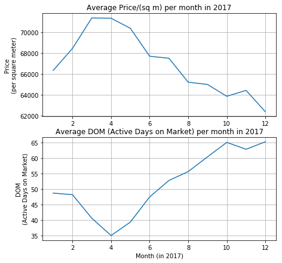

```python
# Matplotlib chart
fig, axs = plt.subplots(2, 1, figsize = (7,7))
axs[0].plot('month', 'price', data = monthly_price)
axs[0].set_ylabel('Price\n(per square meter)')
axs[0].grid(True)
axs[0].set_title('Average Price/(sq m) per month in 2017')
axs[1].plot('month', 'DOM', data = monthly_price)
axs[1].set_xlabel('Month (in 2017)')
axs[1].set_ylabel('DOM\n(Active Days on Market)')
axs[1].set_title('Average DOM (Active Days on Market) per month in 2017')
axs[1].grid(True)
```

The two charts above are very interesting - they are highly consistent. The monthly average home price reached its peak in March and April, and then kept going down to the end of 2017. And the average DOM was changing synchronously and negatively correlated with home price. These two charts together show that the housing market in Beijing was actually going down in 2017.

## 2. Seaborn Chart

Using the jointplot() in seaborn, I can get many informations all in one chart. I am interested in seeing the distribution of home price and construction time (the year of the house being built), and their relationship.

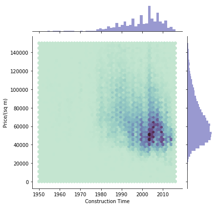

```python
# Seaborn chart
# set the color scheme
cmap = sns.cubehelix_palette(8, start=1, rot=-.75, as_cmap = True)
sns.jointplot('constructionTime', 'price', data = price_filtered, kind = 'hex', color = 'darkblue', cmap = cmap).set_axis_labels('Construction Time', 'Price/(sq m)')
```

It seems like the home price (per square meter) is following a skewed normal distribution, while the construction time is more discrete and changing periodically. The relationship between price and construction time is not very clear on the chart, but it looks like they are slightly negatively correlated. I wouldn't be surprised of that, since houses constructed in early years are mostly located in center city. Beijing has been through a vast urban sprawl in the past 30 years, and housing price of old buildings can be extremely high due to their great locations.

## 3. Altair Chart

To explore a little bit more about the construction time and their locations, I plot the number of transcations in each construction year by districts in Beijing.

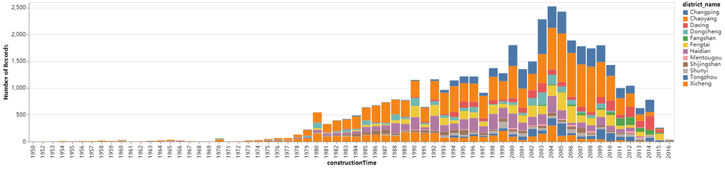

```python
# enable altair to plot larger dataset (row > 5000)
alt.data_transformers.enable('json')

# Altair charts
alt.Chart(price_filtered).mark_bar().encode(
    x = 'constructionTime:O', y = 'count(*):Q', color = 'district_name',
    tooltip = [alt.Tooltip('district_name', title = 'District'),
               alt.Tooltip('count(*):Q', title = 'Number of Transaction')])
```

From the chart above, the biggest takeaways are:

1. For all transactions in 2017, housing constructed around 2004 takes the largest share.
2. Many transactions were in Chaoyang district, and the age of buildings in this district varies a lot - the construction year ranges from 1980 to 2014.
3. It seems like there are many relatively new constructions in Changping district - number of transactions starts to rise since 2000.

I also want to generate a heatmap that indicates the monthly average home price for each district in 2017. So I group the dataset by month and district name, and calculate their means:

```python
# Average home price per month per district
monthly_price_district = price_filtered.groupby(['month', 'district_name'])['price'].mean().round()
monthly_price_district = monthly_price_district.reset_index()
monthly_price_district.head()
```

|  | month | district_name | price |
| --- | --- | --- | --- |
| 0 | 1 | Changping | 43412.0 |
| 1 | 1 | Chaoyang | 65984.0 |
| 2 | 1 | Daxing | 45832.0 |
| 3 | 1 | Dongcheng | 93583.0 |
| 4 | 1 | Fangshan | 34784.0 |

```python
# minimum and maximum monthly average home price
print(monthly_price_district['price'].min(), monthly_price_district['price'].max())
```

```
34784.0 118188.0
```

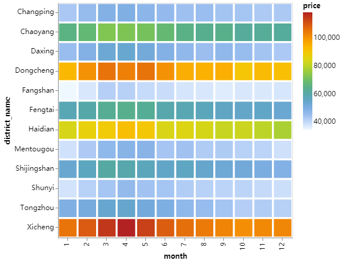

```python
# color scheme
scale = alt.Scale(range=['#F0F8FF', 'cornflowerblue', 'mediumseagreen', '#FFEE00', 'darkorange', 'firebrick'],
                 type = 'sequential', domain = [34784, 40000, 50000, 70000, 100000, 118188])

# heatmap
alt.Chart(monthly_price_district).mark_rect().encode(
    x = 'month:O', y = 'district_name:N',
    color = alt.Color('price:Q', scale = scale),
    tooltip = [alt.Tooltip('price:Q', title = 'Average Price/(sq m)')]).properties(width = 400, height = 400).interactive()
```

Finally, I want to generate a 2-chart dashboard that shows the relationship between home price and construction time for each building type. I group the dataset by building time and construction time, and calculate the average home price for each building type in each construction year.

```python
# Average home price for each building type in each construction year
price_type_const = price_filtered.groupby(['buildingType', 'constructionTime'])['price'].mean().round()
price_type_const = price_type_const.reset_index()

# add the name of building types (from the description on the dataset)
price_type_const.loc[price_type_const['buildingType'] == 1, 'buildingType_name'] = 'Tower'
price_type_const.loc[price_type_const['buildingType'] == 2, 'buildingType_name'] = 'Bungalow'
price_type_const.loc[price_type_const['buildingType'] == 3, 'buildingType_name'] = 'Plate and tower'
price_type_const.loc[price_type_const['buildingType'] == 4, 'buildingType_name'] = 'Plate'

price_type_const.head()
```

|  | buildingType | constructionTime | price | buildingType_name |
| --- | --- | --- | --- | --- |
| 0 | 1.0 | 1970.0 | 110049.0 | Tower |
| 1 | 1.0 | 1979.0 | 89650.0 | Tower |
| 2 | 1.0 | 1980.0 | 80129.0 | Tower |
| 3 | 1.0 | 1981.0 | 95105.0 | Tower |
| 4 | 1.0 | 1982.0 | 85296.0 | Tower |

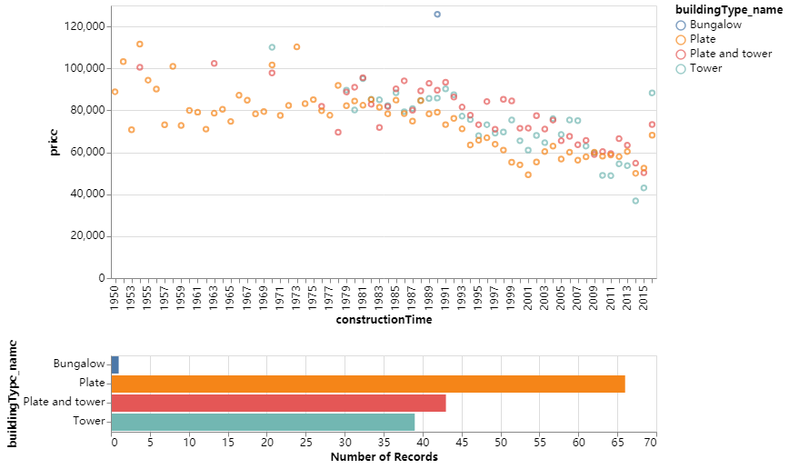

```python
brush = alt.selection(type = 'interval')

# the top scatter plot
scatterplot = alt.Chart(price_type_const).mark_point().encode(
    x = 'constructionTime:O', y = 'price:Q',
    color = alt.condition(brush, 'buildingType_name:N', alt.value('lightgray')),
    tooltip = [alt.Tooltip('price:Q', title = 'Average Price/(sq m)'),
               alt.Tooltip('buildingType_name:N', title = 'Building Type')]).properties(selection = brush, width = 600)

# the botton bar chart
barchart = alt.Chart(price_type_const).mark_bar().encode(
    y = 'buildingType_name:N',
    color = 'buildingType_name:N',
    x = 'count(buildingType):Q',
    tooltip = [alt.Tooltip('count(buildingType):Q', title = 'Count')]).transform_filter(brush.ref()).properties(width = 600)

# align two charts vertically
alt.vconcat(scatterplot, barchart)
```